# Analysis of Alzheimers

## Evan McClintock | CMSC320

# Introduction

The objective of this project is to analyze [this dataset](https://chronicdata.cdc.gov/Healthy-Aging/Alzheimer-s-Disease-and-Healthy-Aging-Data/hfr9-rurv), an aggregation of responses to medical questions containing roughly 214,000 rows and 39 columns, centering around the effect of Alzheimers on patients ages 50+. I chose this dataset with the goal of extracting trends regarding an illness I have no prior knowledge of, besides what Alzheimers is and how it worsens memory function for the older side of the population. The idea is that having little previous knowledge of these trends from any other sources, I won't know "where to look", and will be a relatively unbiased analyser.

Aslo of note is that I have basically no information about the questions asked or values contained in the dataset, besides the names of the column headers. I had a lot of trouble finding an actual description of column values or the questions/codes within. The data was sourced from the CDC, specifically the [Behavioral Risk Factor Surveillance System (BRFSS)](https://www.cdc.gov/brfss/), which I've found quite tricky to navigate. The best I dug up was [this code book](https://www.cdc.gov/brfss/annual_data/2020/pdf/codebook20_llcp-v2-508.pdf), which matches to a few of the codes discovered below (such as C01 for the Overall Health class), but not much else. The only other piece of information I have is the dataset title: "Alzheimer's Disease and Healthy Aging Data" from 2015-2020.

I've decided to roll with it! I believe 'just figuring it out as you go' is a severely underrrated skill, and one most of us will be forced to use many times during our CS career. It isn't a skill that can be tought from theory, like regression, but only by experience; this project is designed as a guide to 'just figuring out' an enormous dataset with little context beforehand, and seeing what we can do with it. It makes the objective two-fold: figure out what the data is representing in the first place/how it's organized, and seeing if we can't find any trends within and make some observations.

Our first step is to import the dataset (I do this via a local csv file which is quicker but it works just as fine with the web link; just uncomment the 'path =' code below). Let's get started with identifying important columns.

### Cleaning the data

```python
#Stardard imports
import pandas as pd
import matplotlib.pyplot as plt
import numpy as np
import copy
import math
#Used for printing in bold
BOLD = '\033[1m'
END = '\033[0m'

path = "AlzheimersData.csv"
#path = "https://chronicdata.cdc.gov/api/views/hfr9-rurv/rows.csv"
```

```python
#Define types for certain columns so we don't have to cast them later.
#There was also a few '.' values in the Data_Value column that wouldn't parse, so we make those NaN
data = pd.read_csv(path, na_values = ".", dtype = {"Data_Value_Type": "string", "LocationAbbr": "string", "LocationDesc": "string", "Class": "string",
                    "Topic": "string", "Question": "string", "Data_Value_Footnote": "string"})
print(BOLD + "Data columns/types" + END)
print(data.dtypes)
data.iloc[:, [20, 21, 22, 23, 32, 33, 34, 35]].sample(n=15, random_state = 1)
```

```
Data columns/types
RowId                         float64
YearStart                       int64
YearEnd                         int64
LocationAbbr                   string
LocationDesc                   string
Datasource                     object
Class                          string
Topic                          string
Question                       string
Response                      float64
Data_Value_Unit                object
DataValueTypeID                object
Data_Value_Type                string
Data_Value                    float64
Data_Value_Alt                float64
Data_Value_Footnote_Symbol     object
Data_Value_Footnote            string
Low_Confidence_Limit          float64
High_Confidence_Limit         float64
Sample_Size                   float64
StratificationCategory1        object
Stratification1                object
StratificationCategory2        object
Stratification2                object
StratificationCategory3       float64
Stratification3               float64
Geolocation                    object
ClassID                        object
TopicID                        object
QuestionID                     object
ResponseID                    float64
LocationID                      int64
StratificationCategoryID1      object
StratificationID1              object
StratificationCategoryID2      object
StratificationID2              object
StratificationCategoryID3     float64
StratificationID3             float64
Report                        float64
dtype: object
```

|  | StratificationCategory1 | Stratification1 | StratificationCategory2 | Stratification2 | StratificationCategoryID1 | StratificationID1 | StratificationCategoryID2 | StratificationID2 |
| --- | --- | --- | --- | --- | --- | --- | --- | --- |
| 117627 | Age Group | 65 years or older | NaN | NaN | AGE | 65PLUS | OVERALL | OVERALL |
| 200884 | Age Group | 65 years or older | Race/Ethnicity | Asian/Pacific Islander | AGE | 65PLUS | RACE | ASN |
| 202900 | Age Group | 65 years or older | Race/Ethnicity | White, non-Hispanic | AGE | 65PLUS | RACE | WHT |
| 161433 | Age Group | Overall | NaN | NaN | AGE | AGE_OVERALL | OVERALL | OVERALL |
| 172755 | Age Group | 65 years or older | NaN | NaN | AGE | 65PLUS | OVERALL | OVERALL |
| 97445 | Age Group | Overall | Race/Ethnicity | White, non-Hispanic | AGE | AGE_OVERALL | RACE | WHT |
| 12037 | Age Group | 65 years or older | Gender | Female | AGE | 65PLUS | GENDER | FEMALE |
| 96495 | Age Group | 50-64 years | Gender | Male | AGE | 5064 | GENDER | MALE |
| 920 | Age Group | Overall | Gender | Male | AGE | AGE_OVERALL | GENDER | MALE |
| 170959 | Age Group | 50-64 years | Race/Ethnicity | Native Am/Alaskan Native | AGE | 5064 | RACE | NAA |
| 119740 | Age Group | 65 years or older | Gender | Male | AGE | 65PLUS | GENDER | MALE |
| 116355 | Age Group | Overall | Race/Ethnicity | Asian/Pacific Islander | AGE | AGE_OVERALL | RACE | ASN |
| 43608 | Age Group | 50-64 years | Race/Ethnicity | Asian/Pacific Islander | AGE | 5064 | RACE | ASN |
| 34064 | Age Group | 65 years or older | Race/Ethnicity | Hispanic | AGE | 65PLUS | RACE | HIS |
| 105430 | Age Group | 65 years or older | Race/Ethnicity | Hispanic | AGE | 65PLUS | RACE | HIS |

We see a ton of columns that we can trash right off the bat. All the data is from BRFSS so we discard Datasource, Data_Value_Alt which contains the same info as Data_Value but sometimes as an integer instead of a float, a bunch of empty columns, etc. We do see columns like Topic, Question, Reponse, and various stratifications, so we'll focus on those in a bit. Let's rename some of the columns to make them more legible.

```python
#Many of the columns are empty
data.drop(columns = ["RowId", "Datasource", "Response", "Data_Value_Unit", "Data_Value_Footnote_Symbol", "Sample_Size",
                     "StratificationCategory3", "Stratification3","StratificationCategoryID3", "StratificationID3", "Report", "Data_Value_Alt",
                     "ResponseID", "Geolocation", "Low_Confidence_Limit", "High_Confidence_Limit", "Data_Value_Footnote"], inplace = True)

#And many have long names that take up space
data.rename(columns = {"Data_Value_Type": "Type", "Data_Value": "Value", "LocationAbbr": "StateAbbr", "LocationDesc": "State"}, inplace = True)
print(BOLD + "Shape: " + str(data.shape) + END)
print(BOLD + "Data columns/types" + END)
print(data.dtypes)
data.iloc[:, 4:15].head(3)
```

```
Shape: (214462, 22)
Data columns/types
YearStart                      int64
YearEnd                        int64
StateAbbr                     string
State                         string
Class                         string
Topic                         string
Question                      string
DataValueTypeID               object
Type                          string
Value                        float64
StratificationCategory1       object
Stratification1               object
StratificationCategory2       object
Stratification2               object
ClassID                       object
TopicID                       object
QuestionID                    object
LocationID                     int64
StratificationCategoryID1     object
StratificationID1             object
StratificationCategoryID2     object
StratificationID2             object
dtype: object
```

|  | Class | Topic | Question | DataValueTypeID | Type | Value | StratificationCategory1 | Stratification1 | StratificationCategory2 | Stratification2 | ClassID |
| --- | --- | --- | --- | --- | --- | --- | --- | --- | --- | --- | --- |
| 0 | Overall Health | Arthritis among older adults | Percentage of older adults ever told they have... | PRCTG | Percentage | 26.3 | Age Group | 50-64 years | NaN | NaN | C01 |
| 1 | Mental Health | Lifetime diagnosis of depression | Percentage of older adults with a lifetime dia... | PRCTG | Percentage | 24.0 | Age Group | 50-64 years | NaN | NaN | C05 |
| 2 | Overall Health | Arthritis among older adults | Percentage of older adults ever told they have... | PRCTG | Percentage | 35.7 | Age Group | 50-64 years | NaN | NaN | C01 |

This isn't a bad start. We see some useful info appearing, but given that the dataframe is 214462 rows long, with a bunch of (to us) meaningless columns, we can't make much use of it

### Figuring out duplicates and codes

We've dealt with the trivial stuff. Let's deal with duplicate columns (and make sure we're not throwing away useful data). While the codebook will, ironically, not actually help us decipher the codes, we easily see a text-code pairing for the following columns: Class, Topic, Question, Location (state), DataValueType, and stratification. Let's see if these have anything to do with each other. Let's get a few functions to help us out.

By far the most important pandas function we use will by *.groupby()*. It allows easy management of data with many attributes (which our's certainly has); the first step to solving a rubix cube is being able to twist individual faces of our choice instead of punching it until something moves. A full explanation of groupby and it's many uses as well as proper syntax can be found [here](https://realpython.com/pandas-groupby/), but on a high level applying groupby on a datafram (df.groupby(column)) will split the data into a bunch of mini dataframe, one for each value of column. Groupby tends to follow the **"split-apply-combine"** formulation, where we **split** into mini dataframes based on the column values, **apply** some operation to the individual dataframes, and **combine** them back into one. We have our first use below.

- *group* will take two attributes and tell us how many of the second attribute there are for each first attribute. Useful for visualizing the distribution of attributes, like what kind of Topics there are for each Class
- *comp_vars* works off of *group*, first showing us the raw value counts for each attribute, then performing the distribution analysis. It's useful for checking the relationship between two columns, in the case of a State Name and State Abbreviation, for example

```python
#For each grpby value in data, the number of cmpby values is listed. Basically divides data by grpby and divides those further by cmpby
def group(data, grpby, cmpby):
    #split by grpby value, take the cmpby values for each dataframe, and perform value count operations on each one.
    #Here we skip the combine step, just printing out useful info
    by_grp = data.groupby(grpby)[cmpby]
    info = pd.DataFrame(by_grp.value_counts())
    return info

#Shows the raw value counts for each variable within the entire dataset, then calls group (showing the distribution between the two variables)
def comp_vars(data, var1, var2):
    print("Value counts for " + BOLD + var1 + END)
    print("==============================================================================")
    print(data[var1].value_counts())
    print("==============================================================================")
    print("\nValue counts for " + BOLD + var2 + END)
    print("==============================================================================")
    print(data[var2].value_counts())
    print("==============================================================================")
    print("\nComparing " + BOLD + var1 + END + " and " + BOLD + var2 + END)
    print("==============================================================================")
    print(group(data, var1, var2))
    print("==============================================================================")
```

```python
comp_vars(data, "Class", "ClassID")
```

```
Value counts for Class
==============================================================================
Overall Health                         71694
Screenings and Vaccines                46867
Nutrition/Physical Activity/Obesity    24851
Cognitive Decline                      19180
Caregiving                             18671
Mental Health                          16600
Smoking and Alcohol Use                16599
Name: Class, dtype: Int64
==============================================================================

Value counts for ClassID
==============================================================================
C01    71694
C03    46867
C02    24851
C06    19180
C07    18671
C05    16600
C04    16599
Name: ClassID, dtype: int64
==============================================================================

Comparing Class and ClassID
==============================================================================
                                             ClassID
Class                               ClassID
Caregiving                          C07        18671
Cognitive Decline                   C06        19180
Mental Health                       C05        16600
Nutrition/Physical Activity/Obesity C02        24851
Overall Health                      C01        71694
Screenings and Vaccines             C03        46867
Smoking and Alcohol Use             C04        16599
==============================================================================
```

Using our function, dividing the data by the Class value and then further by the ClassID value, we find a one to one relationship between all text-code pairs. There is one ClassID for each Class, and vice versa. This is good news because it means both columns contain the exact same information, as we'd expect.

> (e.g. the class 'Mental Health' has the one code 'C05' and vice versa. If a class had multiple codes, we would see multiple codes appear under 'ClassID' for that class. If a code corresponded to multiple classes, would see duplicates in the 'ClassID' column. This was checked for all other text-code columns, rest assured)

We perform this analysis for many column pairs, and decide to throw away the code columns for variables that have short names like State, Class, Topic, etc (as one column is sufficient to provide us all information) but keep the code for the Questions, which are annoying to work with as strings.

A bit of renaming and reorganizing later, and we've made substantial progress!

```python
#Drop uneeded columns
data.drop(columns = ["ClassID", "TopicID", "LocationID", "DataValueTypeID", "Type", "StratificationCategoryID1", "StratificationID1",
                    "StratificationCategoryID2", "StratificationID2", "StateAbbr"], inplace = True)
#Rename unyieldy column names
data.rename(columns = {"StratificationCategory1":"StratCat1", "Stratification1":"StratValues1", "StratificationCategory2":"StratCat2",
                       "Stratification2":"StratValues2", "QuestionID":"QID"}, inplace = True)
#Reorder columns
data = data[["Class", "Topic", "Question", "QID", "State", "Value", "StratCat1", "StratValues1", "StratCat2", "StratValues2", "YearStart", "YearEnd"]]

datacopy = data.copy(deep = True)     #A copy just in case
print(BOLD + "DataFrame Shape: " + str(data.shape) + END)
data.head(3)
```

```
DataFrame Shape: (214462, 12)
```

|  | Class | Topic | Question | QID | State | Value | StratCat1 | StratValues1 | StratCat2 | StratValues2 | YearStart | YearEnd |
| --- | --- | --- | --- | --- | --- | --- | --- | --- | --- | --- | --- | --- |
| 0 | Overall Health | Arthritis among older adults | Percentage of older adults ever told they have... | Q43 | Hawaii | 26.3 | Age Group | 50-64 years | NaN | NaN | 2020 | 2020 |
| 1 | Mental Health | Lifetime diagnosis of depression | Percentage of older adults with a lifetime dia... | Q27 | Idaho | 24.0 | Age Group | 50-64 years | NaN | NaN | 2017 | 2017 |
| 2 | Overall Health | Arthritis among older adults | Percentage of older adults ever told they have... | Q43 | Idaho | 35.7 | Age Group | 50-64 years | NaN | NaN | 2017 | 2017 |

To get a quick feel for how much data we have, let's look at the ratio of NaNs in Value to the length of the dataset:

- *percent_empty* Gives the ratio of NaN values to the length of the given dataframe

```python
def percent_empty(data):
    num_empty = data["Value"].isna().sum()     #Number of NaN rows
    return num_empty/data.shape[0]*100         #Ratio between that and datafram length
```

```python
percent_empty(data)
```

```
32.56194570599919
```

That's a lot of missing values. But, not actually a great measure of the data we have access to. As you may have noticed, our data is given somewhat raw for each state and year, and further stratified by Age Group, and Sex or Ethnicity. At the base level, for a specific Year, State, Sex, etc. we have the raw data, but much is combined or aggregated into Overall rows.

Let's get rid of the State column. Normally we'd have to group the data and sum over all states, but lucky for us BRFSS aslso gives aggregated columns. This is our saving grace; that the people over at the CDC took some of the "dealing with empty values" off our hands. They aggreagate by state, age, etc, presumably performing reasonable imputations; if there was not enough data taken on white males for question QXX in the 50-64 age group in Maryland during 2017, well, there are many ways of inferring the missing info with reasonable guesses so the entire dataset does not become useless. You could average over the rest of the males or ethnicities for that question, use last year's data, or use the average of the rest of the data as a reasonable guess. If you don't have enough data for the 50-64 year olds or 65+ year olds individually, you still might have enough for the overall age group.

Another thing we don't have that we would need to aggregate the data is the sample sizes: if 20/50 people (40%) surveyed in New York said they didn't like pizza (an outrageous ratio) and 4/5 (80%) people in Maryland answered the same, we would not have 60% not liking pizza, it would be closer to 40% since more New Yorkers were surveyed. We're only given data in percents or means, and would have to perform a weighted average with sample size to correctly aggregate (there was a sample size column that came with the dataset but it was unfortunately barren).

We'll do the same thing for ethnicity, which we're not that interested in right now. Similarly, we'll get rid of the rows for which "StratValue2" is an ethnicity. We'll keep the divide on male vs female but make it it's own column. At this point we also know StratCat1 is just age group so we'll get around to removing that label.

```python
#Drop the rows for individual states/territories
data.drop(data[data["State"] != "United States, DC & Territories"].index, inplace = True)
#Drop the rows for race/ethnicities
data.drop(data[(~data["StratValues2"].isin(["Female", "Male"])) & (~pd.isnull(data["StratValues2"]))].index, inplace = True)
#Drop the column labelers themselves
data.drop(columns = ["State", "StratCat1", "StratCat2"], inplace = True)

#Name NaN values as Overall, which these rows represent
data["StratValues2"] = data["StratValues2"].apply(lambda x: "Overall" if pd.isnull(x) else x)
#Better names
data["StratValues1"].replace("50-64 years", "50-64", inplace = True)
data["StratValues1"].replace("65 years or older", "65+", inplace = True)
data.rename(columns = {"StratValues1": "Age", "StratValues2": "Sex"}, inplace = True)

print("Shape:" + str(data.shape))
data.head()
```

```
Shape:(1704, 9)
```

|  | Class | Topic | Question | QID | Value | Age | Sex | YearStart | YearEnd |
| --- | --- | --- | --- | --- | --- | --- | --- | --- | --- |
| 146997 | Mental Health | Lifetime diagnosis of depression | Percentage of older adults with a lifetime dia... | Q27 | 19.2 | 50-64 | Overall | 2016 | 2016 |
| 148087 | Overall Health | Arthritis among older adults | Percentage of older adults ever told they have... | Q43 | 34.8 | 50-64 | Overall | 2017 | 2017 |
| 148156 | Overall Health | Arthritis among older adults | Percentage of older adults ever told they have... | Q43 | 39.1 | 50-64 | Female | 2017 | 2017 |
| 148242 | Overall Health | Arthritis among older adults | Percentage of older adults ever told they have... | Q43 | 28.7 | 50-64 | Male | 2020 | 2020 |
| 148278 | Overall Health | Physically unhealthy days (mean number of days) | Physically unhealthy days (mean number of days... | Q08 | 5.1 | 50-64 | Male | 2018 | 2018 |

```python
percent_empty(data)
```

```
0.0
```

```python
data[(data["YearEnd"] - data["YearStart"] > 0) & ((data["YearStart"] != 2015) | (data["YearEnd"] != 2020))]
```

|  | Class | Topic | Question | QID | Value | Age | Sex | YearStart | YearEnd |
| --- | --- | --- | --- | --- | --- | --- | --- | --- | --- |

```python
data.insert(4, "TimePeriod", "")

#We need to assign to a column based on the values of other columns in the dataframe. We can do this using .apply() and a lambda expression
#For each row in the dataframe, if it's an aggregate from 2015-2020 we use "Overall", otherwise we just use the year it's talking about
data["TimePeriod"] = data.apply(lambda row: "Overall" if ((row["YearStart"] == 2015) & (row["YearEnd"] == 2020)) else str(row["YearStart"]), axis=1)
data.drop(columns = ["YearStart", "YearEnd"], inplace = True)
data.head()
```

|  | Class | Topic | Question | QID | TimePeriod | Value | Age | Sex |
| --- | --- | --- | --- | --- | --- | --- | --- | --- |
| 146997 | Mental Health | Lifetime diagnosis of depression | Percentage of older adults with a lifetime dia... | Q27 | 2016 | 19.2 | 50-64 | Overall |
| 148087 | Overall Health | Arthritis among older adults | Percentage of older adults ever told they have... | Q43 | 2017 | 34.8 | 50-64 | Overall |
| 148156 | Overall Health | Arthritis among older adults | Percentage of older adults ever told they have... | Q43 | 2017 | 39.1 | 50-64 | Female |
| 148242 | Overall Health | Arthritis among older adults | Percentage of older adults ever told they have... | Q43 | 2020 | 28.7 | 50-64 | Male |
| 148278 | Overall Health | Physically unhealthy days (mean number of days) | Physically unhealthy days (mean number of days... | Q08 | 2018 | 5.1 | 50-64 | Male |

**With that, our data is clean! (enough)**  
**Let's get to analyzing and figuring out just what's in this dataset**

## Examining the data

The most obvious things are the first three columns, which seem to be survey identifiers. And Stratification columns seems to divide the data by certain attributes of the person answering questions.

**Questions Avaliable**  
Let's look at those first three. Keep in mind, at this point we have no idea what kind of questions are being asked, so lets start grouping by column. Here we'll check the distribution of Class and Topic.

```python
group(data, "Class", "Topic")
```

| Class | Topic | Topic |
| --- | --- | --- |
| Caregiving | Duration of caregiving among older adults | 63 |
|  | Expect to provide care for someone in the next... | 63 |
|  | Intensity of caregiving among older adults | 63 |
|  | Provide care for a friend or family member in ... | 63 |
|  | Provide care for someone with cognitive impair... | 63 |
| Cognitive Decline | Functional difficulties associated with subjec... | 63 |
|  | Need assistance with day-to-day activities bec... | 63 |
|  | Subjective cognitive decline or memory loss am... | 63 |
|  | Talked with health care professional about sub... | 63 |
| Mental Health | Frequent mental distress | 54 |
|  | Lifetime diagnosis of depression | 54 |
| Nutrition/Physical Activity/Obesity | No leisure-time physical activity within past ... | 54 |
|  | Obesity | 54 |
|  | Eating 2 or more fruits daily | 27 |
|  | Eating 3 or more vegetables daily | 27 |
| Overall Health | Physically unhealthy days (mean number of days) | 54 |
|  | Recent activity limitations in past month | 54 |
|  | Self-rated health (fair to poor health) | 54 |
|  | Self-rated health (good to excellent health) | 54 |
|  | Disability status, including sensory or mobili... | 45 |
|  | Arthritis among older adults | 36 |
|  | Fair or poor health among older adults with ar... | 36 |
|  | Fall with injury within last year | 27 |
|  | Oral health: tooth retention | 27 |
|  | Prevalence of sufficient sleep | 27 |
|  | Severe joint pain among older adults with arth... | 27 |
|  | Taking medication for high blood pressure | 27 |
| Screenings and Vaccines | Diabetes screening within past 3 years | 54 |
|  | Ever had pneumococcal vaccine | 54 |
|  | Influenza vaccine within past year | 54 |
|  | Cholesterol checked in past 5 years | 27 |
|  | Colorectal cancer screening | 27 |
|  | High blood pressure ever | 27 |
|  | Mammogram within past 2 years | 12 |
|  | Pap test within past 3 years | 12 |
|  | Up-to-date with recommended vaccines and scree... | 12 |
|  | Up-to-date with recommended vaccines and scree... | 12 |
| Smoking and Alcohol Use | Binge drinking within past 30 days | 54 |
|  | Current smoking | 54 |

We find that Class is the most general category of question, each having it's own list of topics to ask about. We infer that there will be multiple questions for each topic (multiple topics for each question would be quite confusing...) We then sort the data by these three identifiers in that order, and split into 7 smaller datasets, one for each Class:

Let's check the same thing for topic and question:

```python
group(data[data["Class"] == "Overall Health"], "Topic", "Question")
```

| Topic | Question | Question |
| --- | --- | --- |
| Arthritis among older adults | Percentage of older adults ever told they have... | 36 |
| Disability status, including sensory or mobili... | Percentage of older adults who report having a... | 45 |
| Fair or poor health among older adults with ar... | Fair or poor health among older adults with do... | 36 |
| Fall with injury within last year | Percentage of older adults who have fallen and... | 27 |
| Oral health: tooth retention | Percentage of older adults who report having l... | 27 |
| Physically unhealthy days (mean number of days) | Physically unhealthy days (mean number of days... | 54 |
| Prevalence of sufficient sleep | Percentage of older adults getting sufficient ... | 27 |
| Recent activity limitations in past month | Mean number of days with activity limitations ... | 54 |
| Self-rated health (fair to poor health) | Percentage of older adults who self-reported t... | 54 |
| Self-rated health (good to excellent health) | Percentage of older adults who self-reported t... | 54 |
| Severe joint pain among older adults with arth... | Severe joint pain due to arthritis among older... | 27 |
| Taking medication for high blood pressure | Percentage of older adults who have been told ... | 27 |

It's actually the case that all topics have only one question; Topic and Question are one-to-one attributes. Topic is more general and doesn't provide as much info, so we'll drop it. Questions are also taking up a large amount of space, so lets just keep the Question IDs and store the ID to Question map in a Series.

```python
datacopy = data.copy(deep = True)
```

```python
data = datacopy.copy(deep = True)

#Get a list of all the questions and corresponding questionIDs, which make them easier to identify
qids = []
qs = []
by_qs = data.groupby("Question")
for q, frame in by_qs:
    qs.append(q)
    qids.append(frame.iloc[0, 3])

#Here's out key for QIDs
key = pd.Series(data  = qs, index = qids)

#And we no longer need these columns
data.drop(columns = ["Topic", "Question"], inplace = True)
data.reset_index(drop = True, inplace = True)

print("Shape: " + str(data.shape))
data.head()
```

```
Shape: (1704, 6)
```

|  | Class | QID | TimePeriod | Value | Age | Sex |
| --- | --- | --- | --- | --- | --- | --- |
| 0 | Mental Health | Q27 | 2016 | 19.2 | 50-64 | Overall |
| 1 | Overall Health | Q43 | 2017 | 34.8 | 50-64 | Overall |
| 2 | Overall Health | Q43 | 2017 | 39.1 | 50-64 | Female |
| 3 | Overall Health | Q43 | 2020 | 28.7 | 50-64 | Male |
| 4 | Overall Health | Q08 | 2018 | 5.1 | 50-64 | Male |

- *print_questions* simply groups the data by Questions and prints each one. Nothing crazy here

```python
#Group the data by Question (using groupby), and itterate over the groupby object, ignoring the frame but printing the question
def print_questions(data):
    by_qs = data.groupby("QID")
    for q, frame in by_qs:
        print(BOLD + q + ": " + END + key[q])
```

```python
#Make the data prettier to look at
data.sort_values(by = ["Class", "QID"], inplace = True)
data.reset_index(drop = True, inplace = True)

#Split into dataframes for each Class
health = data[data["Class"] == "Overall Health"].reset_index(drop = True)
vaccines = data[data["Class"] == "Screenings and Vaccines"].reset_index(drop = True)
nutrition = data[data["Class"] == "Nutrition/Physical Activity/Obesity"].reset_index(drop = True)
cognition = data[data["Class"] == "Cognitive Decline"].reset_index(drop = True)
caregiving = data[data["Class"] == "Caregiving"].reset_index(drop = True)
mental = data[data["Class"] == "Mental Health"].reset_index(drop = True)
drug = data[data["Class"] == "Smoking and Alcohol Use"].reset_index(drop = True)
```

Let's look at the 'Cognitive Decline' class over 2015-2020 and it's questions

```python
#Cognitive Decline for 2015-2020
cog_ov = cognition[cognition["TimePeriod"] == "Overall"]
#Cognitive Decline for individual years, which we drag along until later
cog = cognition[cognition["TimePeriod"] != "Overall"]
print("Shape: " + str(cog.shape))
cog.head(3)
```

```
Shape: (216, 6)
```

|  | Class | QID | TimePeriod | Value | Age | Sex |
| --- | --- | --- | --- | --- | --- | --- |
| 0 | Cognitive Decline | Q30 | 2017 | 10.6 | 50-64 | Female |
| 1 | Cognitive Decline | Q30 | 2018 | 10.7 | Overall | Male |
| 2 | Cognitive Decline | Q30 | 2016 | 11.5 | Overall | Male |

```python
print_questions(cog_ov)
```

```
Q30: Percentage of older adults who reported subjective cognitive decline or memory loss that is happening more often or is getting worse in the preceding 12 months
Q31: Percentage of older adults who reported subjective cognitive decline or memory loss that interferes with their ability to engage in social activities or household chores
Q41: Percentage of older adults who reported that as a result of subjective cognitive decline or memory loss that they need assistance with day-to-day activities
Q42: Percentage of older adults with subjective cognitive decline or memory loss who reported talking with a health care professional about it
```

```python
q31_ov = cog_ov[(cog_ov["QID"] == "Q31")].copy(deep = True)
q31 = cog[(cog["QID"] == "Q31")].copy(deep = True)
q31_ov.sort_values(by = ["Age", "Sex"], inplace = True)
q31.sort_values(by = ["TimePeriod", "Age", "Sex"], inplace = True)
print("Shape: " + str(q31_ov.shape))
q31_ov
```

```
Shape: (9, 6)
```

|  | Class | QID | TimePeriod | Value | Age | Sex |
| --- | --- | --- | --- | --- | --- | --- |
| 65 | Cognitive Decline | Q31 | Overall | 49.0 | 50-64 | Female |
| 101 | Cognitive Decline | Q31 | Overall | 45.0 | 50-64 | Male |
| 69 | Cognitive Decline | Q31 | Overall | 47.2 | 50-64 | Overall |
| 96 | Cognitive Decline | Q31 | Overall | 36.0 | 65+ | Female |
| 110 | Cognitive Decline | Q31 | Overall | 27.7 | 65+ | Male |
| 81 | Cognitive Decline | Q31 | Overall | 32.3 | 65+ | Overall |
| 112 | Cognitive Decline | Q31 | Overall | 42.2 | Overall | Female |
| 89 | Cognitive Decline | Q31 | Overall | 36.3 | Overall | Male |
| 119 | Cognitive Decline | Q31 | Overall | 39.5 | Overall | Overall |

We can do something with this

## Data Visualization | Hypothesis Testing

Attempting to pick out trends within the Cognitive Decline class and gain some insight on the effects of Alzheimer's, we'll make the data visual

We see some preliminary patters we might want to test out. Looks like females tend to answer yes to this question more often than males, and by a significant margin (~6%). We might hypothesize that Alzheimers has a greater impact on females than it does on males, but we'll have to see what the data says. We'll state our null hypothesis: that Alzheimers has an equivalent effect on the subjective cognitive decline of both males and females, ages 50+.

We'll make a bar plot showing the difference in response rates between male and female. In fact, we'll make one for each year so we can see if these trends are consistent over time. The output above just shows the data for the Overall (2015-2020) time period, but we've dragged along an identical version that complements this with just the individual years.

```
Q31: Percentage of older adults who reported subjective cognitive decline or memory loss that interferes with their ability to engage in social activities or household chores
```

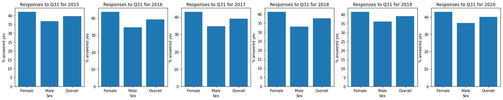

```python
#First we'll group by year, only using data from the Overall age group
by_year = q31[q31["Age"] == "Overall"].groupby("TimePeriod")
#Appropriate dimensions for subplots
fig, ax = plt.subplots(1, len(by_year), figsize = (4*len(by_year), 4))

#We iterate over each year, simply plotting Sex vs Value, which in this case is the percentage of that groups responding in the affirmative to the below question
print(BOLD + "Q31" + ": " + END + key["Q31"])
i = 0
for year, frame in by_year:
    ax[i].bar(frame["Sex"], frame["Value"])
    ax[i].set_xlabel("Sex")
    ax[i].set_ylabel("% answered yes")
    ax[i].set_title("Responses to Q31 for %i" % int(year))
    i += 1
```

Looks promising, but there's a better way to do this. The above shows why bar plots are very *meh*. You can compare within the plot, but each plot uses different y-values. We could set the range of each one manually, but it's still tough to look at. There's just a lot of wasted space.

We'll use a line plot instead. In addition, we'll make it plot **any** question over time, and we'll also have the option to split the data by Age.

- *plot_question_over_time* This function can use the data array, question ID, and split that you give it, and perform many of the above calculations automatically while making everything look all pretty. Namely, it identifies the correct question entires, gets rid of the extra information from whichever category we did **not** give it (either Age or Sex), groups the data by the category we did give it, and plots the values over time for each group

```python
def plot_question_over_time(data, question, group):
    print("\n====================================================================================")
    #We don't want Overall to show up as a year
    data = data[data["TimePeriod"] != "Overall"]
    q = data[(data["QID"] == question)].copy(deep = True)
    q.sort_values(by = ["TimePeriod", "Age", "Sex"], inplace = True)

    #Get rid of extra info (only use the aggregated rows) for the other category
    groups = ["Age", "Sex"]
    groups.remove(group)
    rm = groups[0]
    q = q[q[rm] == "Overall"]

    #Print out the actual question for context
    print(BOLD + question + ": " + END + key[question])
    #Group by the given category and plot the question value over time for each group
    fig, ax = plt.subplots(figsize = (8, 4))
    grouped = q.groupby(group)
    for g, frame in grouped:
        ax.plot(frame["TimePeriod"], frame["Value"], label = g)
    plt.legend(bbox_to_anchor = (1, 1))
    ax.set_xlabel("Year")
    ax.set_title("Responses to Q31 split by %s over time" % group)
    plt.show()
    print("====================================================================================")
```

```
====================================================================================
Q31: Percentage of older adults who reported subjective cognitive decline or memory loss that interferes with their ability to engage in social activities or household chores
```

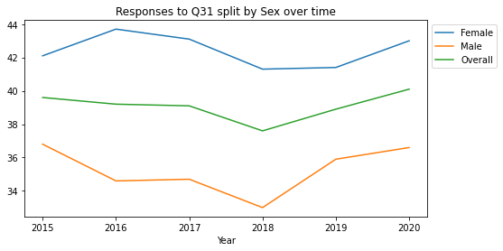

```python
plot_question_over_time(cognition, "Q31", "Sex")
```

Not too bad, we're finally getting some info. Looks like females report cognitive decline or memory loss interfering with daily activites more frequently than males do, specifically over the years from 2015 to 2020. Good data to support the alternate hypothesis. Specifically, we see a ~6-8% difference in the response rates. It's important to note that while a similar observation could be made just by looking at the male vs female responses over all years:

```python
print("Males: %0.1f" % cognition.loc[89, "Value"])
print("Females: %0.1f" % cognition.loc[112, "Value"])
```

```
Males: 36.3
Females: 42.2
```

This does not do as much to test our theory. It says nothing about the years aggregated over, and the male vs female response rate could've shifted over these years, averaging out to the numbers above. A graph also gives an immediate visual indicator that our [brains can process quickly](https://docs.google.com/presentation/d/1CufbhmL4lxwQE02dZBN7iI37KAJbzGUh5LSqENQmMkA/edit#slide=id.p) , in this case providing more information at a faster speed.

```python
print_questions(cognition)
```

```
Q30: Percentage of older adults who reported subjective cognitive decline or memory loss that is happening more often or is getting worse in the preceding 12 months
Q31: Percentage of older adults who reported subjective cognitive decline or memory loss that interferes with their ability to engage in social activities or household chores
Q41: Percentage of older adults who reported that as a result of subjective cognitive decline or memory loss that they need assistance with day-to-day activities
Q42: Percentage of older adults with subjective cognitive decline or memory loss who reported talking with a health care professional about it
```

Taking a look at what else is avaliable to us, we see that Q30 and Q41, when answered in the affirmative, point towards more severe cognitive decline and increased effects in daily life. We'll split on Sex and plot for these as well as Q42 and our previous Q31 above, to have everything in the same place.

```
====================================================================================
Q30: Percentage of older adults who reported subjective cognitive decline or memory loss that is happening more often or is getting worse in the preceding 12 months
```

[figure not shown]

```
====================================================================================

====================================================================================
Q31: Percentage of older adults who reported subjective cognitive decline or memory loss that interferes with their ability to engage in social activities or household chores
```

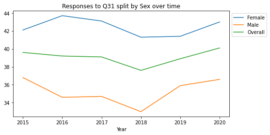

```
====================================================================================

====================================================================================
Q41: Percentage of older adults who reported that as a result of subjective cognitive decline or memory loss that they need assistance with day-to-day activities
```

[figure not shown]

```
====================================================================================

====================================================================================
Q42: Percentage of older adults with subjective cognitive decline or memory loss who reported talking with a health care professional about it
```

[figure not shown]

```python
for question in cognition["QID"].value_counts().index:
    plot_question_over_time(cognition, question, "Sex")
```

Q30 asks the participants if they've noticed a decrease in memory function in the last year. Are females affected more than males? The graph says no. females are slightly above males for the last three years, and males are slightly above for the first three. We should note the steep drop from ~11.5% in 2019 to ~8.5% in 2020 for both sexes. While it's possible that this represents the actual data, it is more likely an error in the data taking for that specific question, as the trend does not appear in the following graphs.

Q31 we just looked at (memory loss interfering with daily activities). Q41 asks the participants if they've needed assistance with that cognitive decline. A similar trend appears, in which females answer in the affirmative more frequently than males across all years. Q42 asks if they've talked to a health care professional about it, with the results showing a similar trend.

While this does provide good evidence towards the alternate hypothesis, it is subsantially more qualitative than quantitative. Unfortunately I did not leave myself enough time to fully complete this part of the project, which I apologize for. A propoer analysis would look at the standard deviations in these rates, fit a gaussian distribution, and evaluate the probability that the values we see here were obtained at random. While it certainly looks good, the alternate hypothesis was never proven.

```
====================================================================================
Q31: Percentage of older adults who reported subjective cognitive decline or memory loss that interferes with their ability to engage in social activities or household chores
```

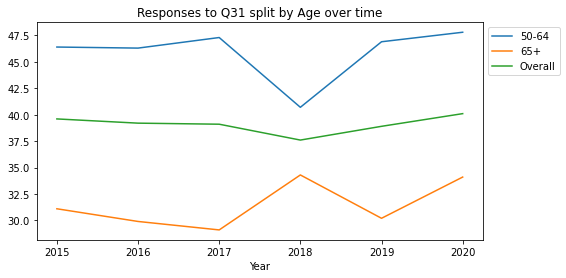

```python
plot_question_over_time(cognition, "Q31", "Age")
```

We also plotted for age. We see the 50-64 year olds answering yes more frequently than the 65+ year olds. That's an interesting and unexpected discovery. We'll have to look into it a bit more. Let's see what other questions we have access to.

```python
print_questions(health)
```

```
Q04: Percentage of older adults who have been told they have high blood pressure who report currently taking medication for their high blood pressure
Q05: Percentage of older adults who have fallen and sustained an injury within last year
Q07: Percentage of older adults who report having lost 5 or fewer teeth due to decay or gum disease
Q08: Physically unhealthy days (mean number of days in past month)
Q32: Percentage of older adults who self-reported that their health is "fair" or "poor"
Q33: Percentage of older adults who self-reported that their health is "good", "very good", or "excellent"
Q34: Percentage of older adults getting sufficient sleep (>6 hours)
Q35: Mean number of days with activity limitations in the past month
Q43: Percentage of older adults ever told they have arthritis
Q44: Severe joint pain due to arthritis among older adults with doctor-diagnosed arthritis
Q45: Fair or poor health among older adults with doctor-diagnosed arthritis
Q46: Percentage of older adults who report having a disability (includes limitations related to sensory or mobility impairments or a physical, mental, or emotional condition)
```

```
====================================================================================
Q46: Percentage of older adults who report having a disability (includes limitations related to sensory or mobility impairments or a physical, mental, or emotional condition)
```

[figure not shown]

```
====================================================================================

====================================================================================
Q46: Percentage of older adults who report having a disability (includes limitations related to sensory or mobility impairments or a physical, mental, or emotional condition)
```

[figure not shown]

```python
question = "Q46"
plot_question_over_time(health, question, "Sex")
plot_question_over_time(health, question, "Age")
```

There's a lot more we could do with this data and the functions avaliable to us, not all of which I got to. It would be interesting to see trends for other questions in other Classes, like the few displayed above. Unfortunately the end of the data pipeline trailed off a bit, but we got a massive insight into the data cleaning process, figuring out how the data was represented, interpreting it, etc. which was a huge part of the goal. On the second half, we got a partial insight into the trends that could come from this data; more to explore at a later data.